# Лабораторная работа №8

Операционные системы

Лебеденко Е.В.

Российский университет дружбы народов, Москва, Россия

4 апреля 2026

# Информация

## Докладчик

- Лебеденко Елена Викторовна
- Студент НКАбд-04-25
- Российский университет дружбы народов
- 1032253535@rudn.ru

# Цель работы

Ознакомление с инструментами поиска файлов и фильтрации текстовых данных. Приобретение практических навыков: по управлению процессами (и заданиями), по проверке использования диска и обслуживанию файловых систем.

# Задание

1. Осуществите вход в систему, используя соответствующее имя пользователя.
2. Запишите в файл file.txt названия файлов, содержащихся в каталоге /etc. Допишите в этот же файл названия файлов, содержащихся в вашем домашнем каталоге.
3. Выведите имена всех файлов из file.txt, имеющих расширение .conf, после чего запишите их в новый текстовой файл conf.txt.
4. Определите, какие файлы в вашем домашнем каталоге имеют имена, начинавшиеся с символа c? Предложите несколько вариантов, как это сделать.
5. Выведите на экран (по странично) имена файлов из каталога /etc, начинающиеся с символа h.
6. Запустите в фоновом режиме процесс, который будет записывать в файл ~/logfile файлы, имена которых начинаются с log.
7. Удалите файл ~/logfile.
8. Запустите из консоли в фоновом режиме редактор gedit.
9. Определите идентификатор процесса gedit, используя команду ps, конвейер и фильтр grep. Как ещё можно определить идентификатор процесса?
10. Прочтите справку (man) команды kill, после чего используйте её для завершения процесса gedit.
11. Выполните команды df и du, предварительно получив более подробную информацию об этих командах, с помощью команды man.
12. Воспользовавшись справкой команды find, выведите имена всех директорий, имеющихся в вашем домашнем каталоге.

# Теоретическое введение

В операционной системе Linux каждая команда использует три стандартных потока: stdin (ввод), stdout (вывод) и stderr (вывод ошибок). Эти потоки можно перенаправлять в файлы с помощью символов >, >>, 2> или связывать между собой через конвейер (|). Для поиска файлов по различным критериям используется команда find, а для фильтрации текстовых строк — команда grep. Каждый запущенный процесс получает уникальный идентификатор (PID), а управление процессами осуществляется командами ps, jobs и kill. Фоновый режим выполнения позволяет запускать длительные задачи, не блокируя консоль, добавляя в конце команды символ &. Для оценки использования дискового пространства применяются команды df (информация о разделах) и du (размер каталогов и файлов).

# Выполнение лабораторной работы

Записываю в файл file.txt названия файлов, содержащихся в каталоге /etc. Дописываю в этот же файл названия файлов, содержащихся в моём домашнем каталоге.

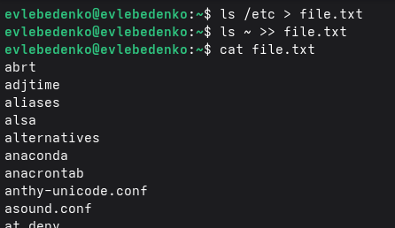

> и >>

Вывожу имена всех файлов из file.txt, имеющих расширение .conf, после чего записываю их в новый текстовой файл conf.txt.

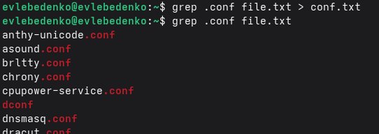

grep conf

Определяю, какие файлы в вашем домашнем каталоге имеют имена, начинавшиеся с символа c. Пишу несколько вариантов, как это сделать.

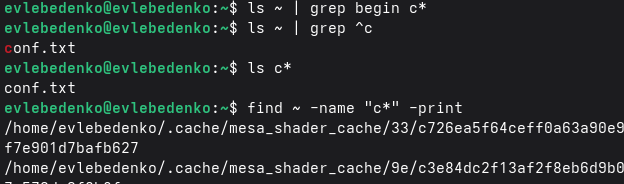

ls | grep

Вывожу на экран (по странично) имена файлов из каталога /etc, начинающиеся с символа h.

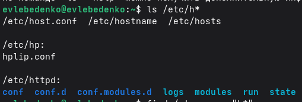

Удаляю файл ~/logfile. Запускаю из консоли в фоновом режиме редактор gedit.

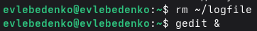

gedit

Определяю идентификатор процесса gedit, используя команду ps, конвейер и фильтр grep. Читаю справку (man) команды kill, после чего использую её для завершения процесса gedit.

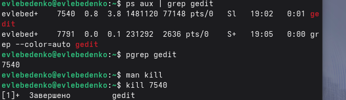

kill

Выполняю команды df и du, предварительно получив более подробную информацию об этих командах с помощью команды man.

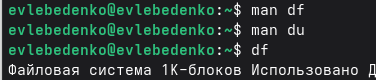

df и du

Воспользовавшись справкой команды find, вывожу имена всех директорий, имеющихся в вашем домашнем каталоге.

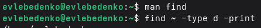

find -type d

# Выводы

Во время выполнения лабораторной работы я ознакомилась с инструментами поиска файлов и фильтрации текстовых данных, приобрела практические навыки: по управлению процессами (и заданиями), по проверке использования диска и обслуживанию файловых систем.